# MTH6139 Time Series Forecasting with Prophet

Mohammad Usman Naveed

March 10, 2026

# 1 Introduction

Time series analysis is concerned with data collected over time. In this project, we are concerned with analyzing atmospheric data on CO2 and forecasting future values of atmospheric CO2 using Meta’s Prophet forecasting system in R.

Prophet is a data forecasting tool that is particularly useful for forecasting data that exhibits strong trends and seasonal patterns.

## #2 Dataset Description

The dataset used in this project is **co2 dataset** available in R.

The dataset contains monthly data on atmospheric carbon dioxide collected at the Mauna Loa Observatory in Hawaii.

The data starts from 1959 and exhibits trends over long periods of time.

# 3 Load Libraries

```r
library(prophet)
library(zoo)
```

# 4 Load and Visualize the Data

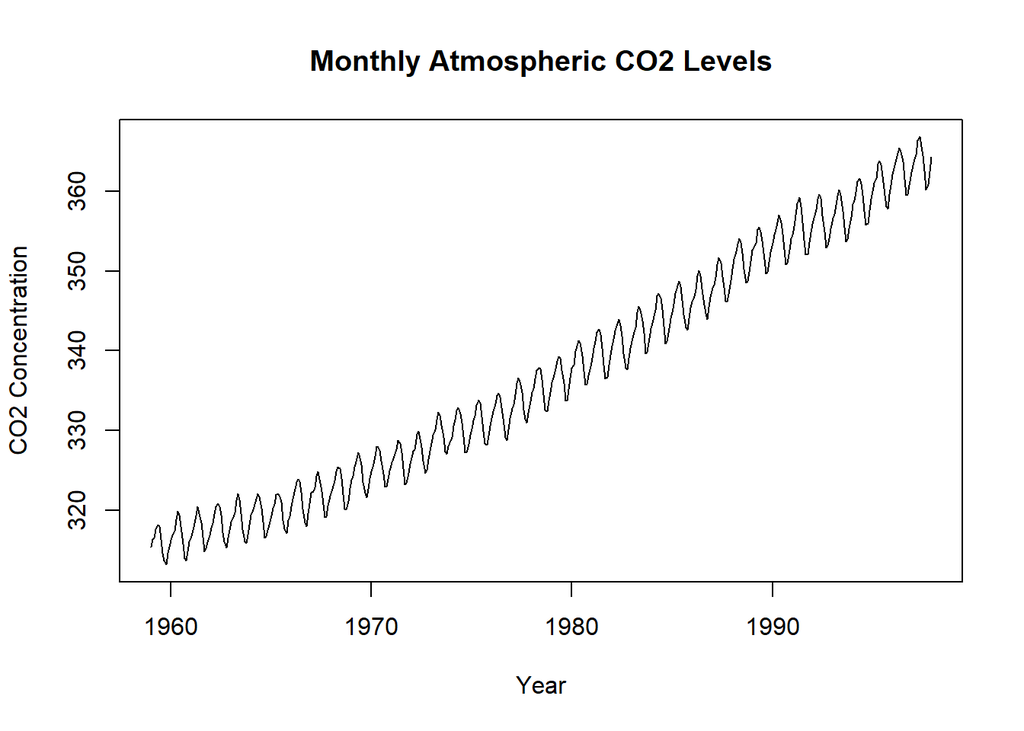

```r
data(co2)

plot(co2,
     main="Monthly Atmospheric CO2 Levels",
     ylab="CO2 Concentration",
     xlab="Year")
```

From the plot we observe:

• CO2 levels increase steadily over time • There is a repeating yearly seasonal pattern

# 5 Convert Data for Prophet

Prophet requires a dataframe with two columns:

• ds → date • y → observed value

```r
time_index <- time(co2)

co2_dataframe <- data.frame(
  ds = as.Date(as.yearmon(time_index)),
  y = as.numeric(co2)
)

head(co2_dataframe)
```

```
##           ds      y
## 1 1959-01-01 315.42
## 2 1959-02-01 316.31
## 3 1959-03-01 316.50
## 4 1959-04-01 317.56
## 5 1959-05-01 318.13
## 6 1959-06-01 318.00
```

# 6 Fit Prophet Model

```r
prophet_model <- prophet(co2_dataframe)
```

```
## Disabling weekly seasonality. Run prophet with weekly.seasonality=TRUE to override this.
```

```
## Disabling daily seasonality. Run prophet with daily.seasonality=TRUE to override this.
```

The Prophet model decomposes the time series into trend, seasonality and noise.

# 7 Forecast Future Values

```r
future_dates <- make_future_dataframe(prophet_model,
                                      periods = 24,
                                      freq="month")

forecast <- predict(prophet_model, future_dates)

head(forecast)
```

```
##           ds    trend additive_terms additive_terms_lower additive_terms_upper
## 1 1959-01-01 315.3626     -0.0775880           -0.0775880           -0.0775880
## 2 1959-02-01 315.4469      0.5946394            0.5946394            0.5946394
## 3 1959-03-01 315.5230      1.2325855            1.2325855            1.2325855
## 4 1959-04-01 315.6073      2.4609156            2.4609156            2.4609156
## 5 1959-05-01 315.6888      3.0206586            3.0206586            3.0206586
## 6 1959-06-01 315.7731      2.3515302            2.3515302            2.3515302
##       yearly yearly_lower yearly_upper multiplicative_terms
## 1 -0.0775880   -0.0775880   -0.0775880                    0
## 2  0.5946394    0.5946394    0.5946394                    0
## 3  1.2325855    1.2325855    1.2325855                    0
## 4  2.4609156    2.4609156    2.4609156                    0
## 5  3.0206586    3.0206586    3.0206586                    0
## 6  2.3515302    2.3515302    2.3515302                    0
##   multiplicative_terms_lower multiplicative_terms_upper yhat_lower yhat_upper
## 1                          0                          0   314.8165   315.7214
## 2                          0                          0   315.5765   316.5396
## 3                          0                          0   316.2851   317.2147
## 4                          0                          0   317.6000   318.5392
## 5                          0                          0   318.2601   319.1607
## 6                          0                          0   317.6787   318.5894
##   trend_lower trend_upper     yhat
## 1    315.3626    315.3626 315.2850
## 2    315.4469    315.4469 316.0415
## 3    315.5230    315.5230 316.7556
## 4    315.6073    315.6073 318.0682
## 5    315.6888    315.6888 318.7095
## 6    315.7731    315.7731 318.1247
```

The forecast dataframe includes:

• yhat → predicted values • yhat_lower → lower bound • yhat_upper → upper bound

# 8 Plot Forecast

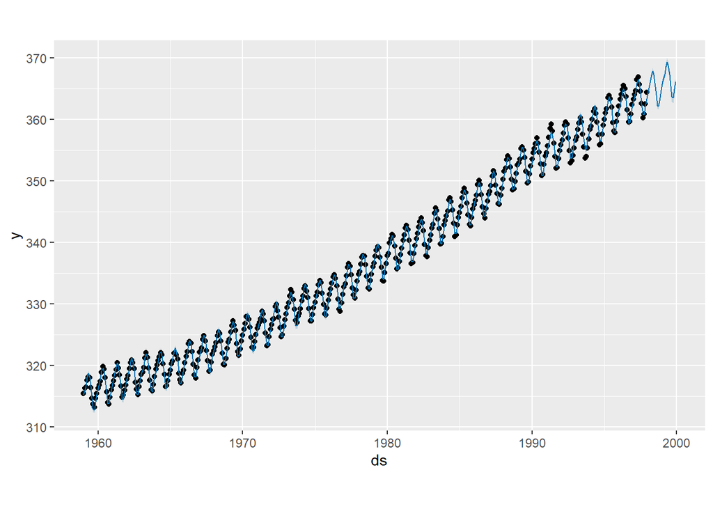

```r
plot(prophet_model, forecast)
```

The black dots represent historical data and the blue line represents the predicted trend.

# 9 Prophet Components

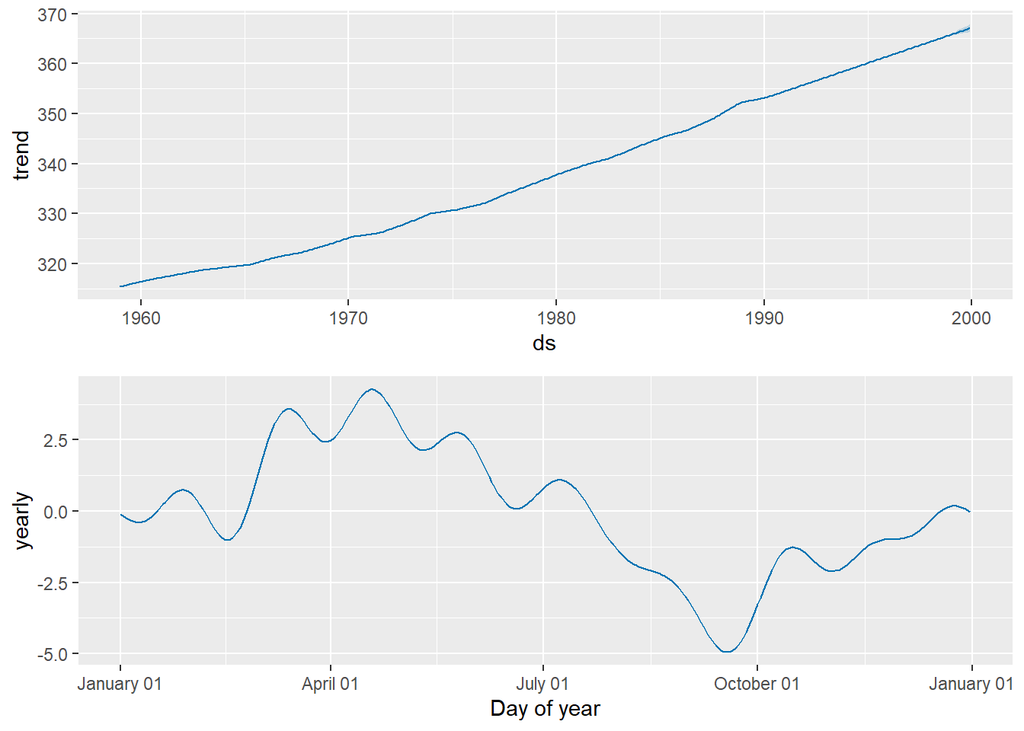

```r
prophet_plot_components(prophet_model, forecast)
```

This plot shows the decomposition of the time series into:

• long-term trend • yearly seasonal pattern

# 10 Additional Visualization

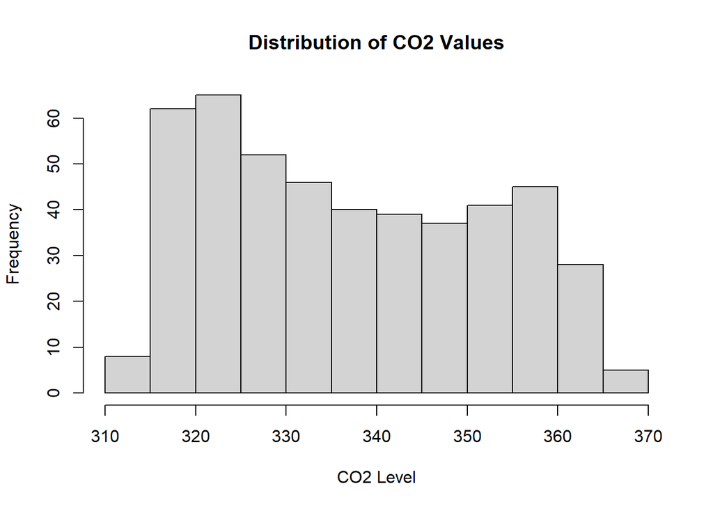

```r
hist(co2_dataframe$y,
     main="Distribution of CO2 Values",
     xlab="CO2 Level")
```

# 11 Linear Trend Model

```r
time_numeric <- 1:length(co2_dataframe$y)

linear_model <- lm(co2_dataframe$y ~ time_numeric)

summary(linear_model)
```

```
##
## Call:
## lm(formula = co2_dataframe$y ~ time_numeric)
##
## Residuals:
##     Min      1Q  Median      3Q     Max
## -6.0399 -1.9476 -0.0017  1.9113  6.5149
##
## Coefficients:
##               Estimate Std. Error t value Pr(>|t|)
## (Intercept)  3.115e+02  2.424e-01  1284.9   <2e-16 ***
## time_numeric 1.090e-01  8.958e-04   121.6   <2e-16 ***
## ---
## Signif. codes:  0 '***' 0.001 '**' 0.01 '*' 0.05 '.' 0.1 ' ' 1
##
## Residual standard error: 2.618 on 466 degrees of freedom
## Multiple R-squared:  0.9695, Adjusted R-squared:  0.9694
## F-statistic: 1.479e+04 on 1 and 466 DF,  p-value: < 2.2e-16
```

The regression analysis confirms the trends in atmospheric CO2.

# 12 Conclusion

In this project, we analyzed atmospheric data on CO2 using Meta’s Prophet forecasting model.

The results show that atmospheric CO2 exhibits strong trends and seasonal patterns.

Prophet successfully captures these trends and seasonal patterns in atmospheric data on CO2 and generates forecasts for future values of atmospheric CO2.